# Parte 2

Mayela Fosado

31/3/2022

# Anotación genómica de los resultados del alineamiento

## Cargar las librerías

```r
library(Biobase)
library(IRanges)
```

## Introducción IRanges

### Inicio y final de cada rango.

```r
x <- IRanges(start = c(11, 35, 40), end = c(20, 50, 63))
x
```

```
## IRanges object with 3 ranges and 0 metadata columns:
##           start       end     width
##       <integer> <integer> <integer>
##   [1]        11        20        10
##   [2]        35        50        16
##   [3]        40        63        24
```

### Extraer información

```r
start(x) # Todos los inicios
```

```
## [1] 11 35 40
```

```r
end(x)   # Todos los finales
```

```
## [1] 20 50 63
```

```r
width(x) # Ancho de cada rango
```

```
## [1] 10 16 24
```

```r
range(x) # Rango total de todos
```

```
## IRanges object with 1 range and 0 metadata columns:
##           start       end     width
##       <integer> <integer> <integer>
##   [1]        11        63        53
```

### Más funciones:

```r
coverage(x) # La suma de la cobertura en cada posición
```

```
## integer-Rle of length 63 with 6 runs
##   Lengths: 10 10 14  5 11 13
##   Values :  0  1  0  1  2  1
```

```r
reduce(x)   # Une los rangos que estan encimados
```

```
## IRanges object with 2 ranges and 0 metadata columns:
##           start       end     width
##       <integer> <integer> <integer>
##   [1]        11        20        10
##   [2]        35        63        29
```

### ¿Qué quieren hacer?

Obtenemos datos que nos interesan.

```r
exons <- reduce(x)

reads <- IRanges(start=c(1,21,30,50,80), width=20)

reads
```

```
## IRanges object with 5 ranges and 0 metadata columns:
##           start       end     width
##       <integer> <integer> <integer>
##   [1]         1        20        20
##   [2]        21        40        20
##   [3]        30        49        20
##   [4]        50        69        20
##   [5]        80        99        20
```

Otra función

```r
countOverlaps(exons, reads)
```

```
## [1] 1 3
```

# Anotación de un genoma

## Descargar archivo y cargar librerías

```r
library(rtracklayer)
human <- import("Homo_sapiens_exons_small_e70.gtf")

human
```

```
## GRanges object with 101677 ranges and 11 metadata columns:
##            seqnames            ranges strand |         source     type
##               <Rle>         <IRanges>  <Rle> |       <factor> <factor>
##        [1]       21   9683191-9683272      + |          miRNA     exon
##        [2]       21   9825832-9826011      + |          miRNA     exon
##        [3]       21   9826203-9826263      + |          miRNA     exon
##        [4]       21   9937696-9937777      - |          miRNA     exon
##        [5]       21   9937936-9938018      - |          miRNA     exon
##        ...      ...               ...    ... .            ...      ...
##   [101673]       20 62896611-62896782      + | protein_coding     exon
##   [101674]       20 62899240-62899363      + | protein_coding     exon
##   [101675]       20 62904574-62907583      + | protein_coding     exon
##   [101676]       20 62903550-62903583      + | protein_coding     exon
##   [101677]       20 62904574-62907578      + | protein_coding     exon
##                score     phase         gene_id   transcript_id exon_number
```

[output cut: 27 more lines]

## Acceder y trabajar en el nuevo objeto

```r
seqnames(human)
```

```
## factor-Rle of length 101677 with 4 runs
##   Lengths:  8521 58898 16874 17384
##   Values :    21    2     22    20
## Levels(4): 2 20 21 22
```

```r
ranges(human)
```

```
## IRanges object with 101677 ranges and 0 metadata columns:
##                start       end     width
##            <integer> <integer> <integer>
##        [1]   9683191   9683272        82
##        [2]   9825832   9826011       180
##        [3]   9826203   9826263        61
##        [4]   9937696   9937777        82
##        [5]   9937936   9938018        83
##        ...       ...       ...       ...
##   [101673]  62896611  62896782       172
##   [101674]  62899240  62899363       124
##   [101675]  62904574  62907583      3010
##   [101676]  62903550  62903583        34
##   [101677]  62904574  62907578      3005
```

```r
strand(human)
```

```
## factor-Rle of length 101677 with 2239 runs
##   Lengths:   3   2   2   1   1  80   1   5 ...  59  52   2  59  12  15   6  83
##   Values :   +   -   +   -   +   -   +   - ...   -   +   -   +   -   +   -   +
## Levels(3): + - *
```

```r
mcols(human)
```

```
## DataFrame with 101677 rows and 11 columns
##                source     type     score     phase         gene_id
##              <factor> <factor> <numeric> <integer>     <character>
## 1               miRNA     exon        NA        NA ENSG00000238411
## 2               miRNA     exon        NA        NA ENSG00000264462
## 3               miRNA     exon        NA        NA ENSG00000264063
## 4               miRNA     exon        NA        NA ENSG00000239179
## 5               miRNA     exon        NA        NA ENSG00000239107
## ...               ...      ...       ...       ...             ...
## 101673 protein_coding     exon        NA        NA ENSG00000203880
## 101674 protein_coding     exon        NA        NA ENSG00000203880
## 101675 protein_coding     exon        NA        NA ENSG00000203880
## 101676 protein_coding     exon        NA        NA ENSG00000203880
## 101677 protein_coding     exon        NA        NA ENSG00000203880
##          transcript_id exon_number   gene_name   gene_biotype transcript_name
```

[output cut: 25 more lines]

### Hacer una tabla y manipular datos

```r
table(mcols(human)$gene_biotype)
```

```
##
##        lincRNA          miRNA       misc_RNA     non_coding protein_coding
##           4313            406            273              1          96168
##           rRNA         snoRNA          snRNA
##             65            202            249
```

### Dejar columnas de interés

```r
mcols(human) <- mcols(human)[,c("source","gene_id","gene_name","gene_biotype")]

mcols(human)
```

```
## DataFrame with 101677 rows and 4 columns
##                source         gene_id   gene_name   gene_biotype
##              <factor>     <character> <character>    <character>
## 1               miRNA ENSG00000238411  CR381670.1          miRNA
## 2               miRNA ENSG00000264462     MIR3648          miRNA
## 3               miRNA ENSG00000264063     MIR3687          miRNA
## 4               miRNA ENSG00000239179  CR392039.2          miRNA
## 5               miRNA ENSG00000239107  CR392039.1          miRNA
## ...               ...             ...         ...            ...
## 101673 protein_coding ENSG00000203880      PCMTD2 protein_coding
## 101674 protein_coding ENSG00000203880      PCMTD2 protein_coding
## 101675 protein_coding ENSG00000203880      PCMTD2 protein_coding
## 101676 protein_coding ENSG00000203880      PCMTD2 protein_coding
## 101677 protein_coding ENSG00000203880      PCMTD2 protein_coding
```

## Ejercicios

### ¿Cómo dejar solo anotaciones miRNA?

Con un subset o which, se utilizan para solo obtener los datos que necesites. Se obtiene la información de gene_biotype, y solo queremos lo de miRNA, así que colocamos que solo busque eso.

```r
miRNA <- which(human$gene_biotype == "miRNA")

miRNA
```

```
##   [1]      1      2      3      4      5      7     95    112    117    237
##  [11]    339    340    341    433    517    518    618    719    743   1081
##  [21]   1671   1858   2451   3253   3402   4158   4900   4902   4903   5628
##  [31]   6098   6299   9143   9399  10527  11102  11106  11249  11250  11279
##  [41]  11295  11958  12235  13352  13538  15197  15511  15952  16080  16082
##  [51]  16121  16321  16421  16422  16475  16509  16721  16749  17156  17157
##  [61]  17164  17227  18660  19576  19934  20607  20608  20609  20610  20617
##  [71]  20625  20697  20742  21071  21423  21630  21631  21632  21727  21878
##  [81]  21882  21894  22394  22482  22803  22993  23059  23220  23221  23224
##  [91]  23233  23504  23505  23696  24054  24170  24388  24389  24390  24391
## [101]  24457  25568  26821  26948  26949  27157  27158  27159  27465  28257
## [111]  28464  28635  28669  28771  28833  28836  28839  28903  28904  28909
## [121]  29829  30384  31050  31474  32081  32186  32209  33007  33008  33186
## [131]  33193  33299  33312  33313  33578  33668  34089  34359  34479  34527
## [141]  35030  35312  35684  36073  36941  37328  37386  37394  37522  37561
```

[output cut: 26 more lines]

### Solo con anotaciones de la cadena “-”

Con un subset o which, se utilizan para solo obtener los datos que necesites. Lo mismo que arriba pero solo buscamos en el sentido que aparezca solo los que tienen sentido negativo.

```r
negative <- subset (human, strand (human) == "-")

negative
```

```
## GRanges object with 50854 ranges and 4 metadata columns:
##           seqnames            ranges strand |         source         gene_id
##              <Rle>         <IRanges>  <Rle> |       <factor>     <character>
##       [1]       21   9937696-9937777      - | miRNA          ENSG00000239179
##       [2]       21   9937936-9938018      - | miRNA          ENSG00000239107
##       [3]       21 10380380-10380661      - | misc_RNA       ENSG00000264002
##       [4]       21 10990763-10990920      - | protein_coding ENSG00000166157
##       [5]       21 10987769-10987877      - | protein_coding ENSG00000166157
##       ...      ...               ...    ... .            ...             ...
##   [50850]       20 62714733-62715058      - | protein_coding ENSG00000171695
##   [50851]       20 62715171-62715712      - | protein_coding ENSG00000171695
##   [50852]       20 62714936-62715058      - | protein_coding ENSG00000171695
##   [50853]       20 62714752-62714847      - | protein_coding ENSG00000171695
##   [50854]       20 62737173-62738524      - | protein_coding ENSG00000125522
##             gene_name   gene_biotype
##           <character>    <character>
##       [1]  CR392039.2          miRNA
##       [2]  CR392039.1          miRNA
##       [3] Metazoa_SRP       misc_RNA
##       [4]        TPTE protein_coding
##       [5]        TPTE protein_coding
##       ...         ...            ...
##   [50850]   C20orf201 protein_coding
##   [50851]   C20orf201 protein_coding
##   [50852]   C20orf201 protein_coding
##   [50853]   C20orf201 protein_coding
##   [50854]      NPBWR2 protein_coding
##   -------
##   seqinfo: 4 sequences from an unspecified genome; no seqlengths
```

# Anotación de secuencias mapeadas

Una forma de visualizar las secuencias mapeadas, es por medio de archivos BAM & SAM, también se pueden usar en linux con samtools y aquí en R se utiliza la librería Rsamtools, que vamos a cargar.

```r
library(Rsamtools)
```

Seleccionar los datos del archivo BAM.

- Nombre del cromosoma (sec de ref)
- Cadena
- Posición
- Longitud de la sec mapeada

```r
what <- c("rname", "strand", "pos", "qwidth")

param <- ScanBamParam(what=what)

bam <- scanBam("human_mapped_small.bam", param=param)

class(bam)
```

```
## [1] "list"
```

```r
lapply(bam, names)
```

```
## [[1]]
## [1] "rname"  "strand" "pos"    "qwidth"
```

Construir un GRanges con los datos

```r
mapGR <- GRanges(
   seqnames = bam[[1]]$rname,
   ranges   = IRanges(start=bam[[1]]$pos, width=bam[[1]]$qwidth),
   strand   = bam[[1]]$strand
)

mapGR
```

```
## GRanges object with 787352 ranges and 0 metadata columns:
##            seqnames              ranges strand
##               <Rle>           <IRanges>  <Rle>
##        [1]        5 148808541-148808562      +
##        [2]        9   96938244-96938265      +
##        [3]        5 148808541-148808562      +
##        [4]       17   27188422-27188442      -
##        [5]        9   96938635-96938656      +
##        ...      ...                 ...    ...
##   [787348]        8   41517964-41517983      +
##   [787349]        2 204229171-204229198      -
##   [787350]       19   13947102-13947125      -
##   [787351]        8   98967775-98967789      +
##   [787352]        3   52302353-52302374      -
##   -------
##   seqinfo: 84 sequences from an unspecified genome; no seqlengths
```

Contar ocurrencias de las secuencias cortas dentro de los rangos.

```r
mcols(human)$counts = countOverlaps(human, mapGR)

mcols(human)
```

```
## DataFrame with 101677 rows and 5 columns
##                source         gene_id   gene_name   gene_biotype    counts
##              <factor>     <character> <character>    <character> <integer>
## 1               miRNA ENSG00000238411  CR381670.1          miRNA         0
## 2               miRNA ENSG00000264462     MIR3648          miRNA         0
## 3               miRNA ENSG00000264063     MIR3687          miRNA         0
## 4               miRNA ENSG00000239179  CR392039.2          miRNA         0
## 5               miRNA ENSG00000239107  CR392039.1          miRNA         0
## ...               ...             ...         ...            ...       ...
## 101673 protein_coding ENSG00000203880      PCMTD2 protein_coding         0
## 101674 protein_coding ENSG00000203880      PCMTD2 protein_coding         0
## 101675 protein_coding ENSG00000203880      PCMTD2 protein_coding         0
## 101676 protein_coding ENSG00000203880      PCMTD2 protein_coding         0
## 101677 protein_coding ENSG00000203880      PCMTD2 protein_coding         0
```

Agregar más información de nuestro interés, valores, puede ser por tipo de gen o por gen individual.

```r
typeCounts = aggregate(mcols(human)$counts, by=list("biotype"=mcols(human)$gene_biotype), sum)

typeCounts
```

```
##          biotype      x
## 1        lincRNA    146
## 2          miRNA 123216
## 3       misc_RNA     93
## 4     non_coding      3
## 5 protein_coding  89883
## 6           rRNA      8
## 7         snoRNA    262
## 8          snRNA     42
```

```r
geneCounts = aggregate(mcols(human)$counts, by=list("id"=mcols(human)$gene_name), sum)

head(geneCounts)
```

```
##       id x
## 1    7SK 3
## 2 A4GALT 0
## 3   AAK1 0
## 4   AAMP 8
## 5   AAR2 0
## 6 ABCA12 0
```

### Distribución de secuencias cortas en los distintos biotipos

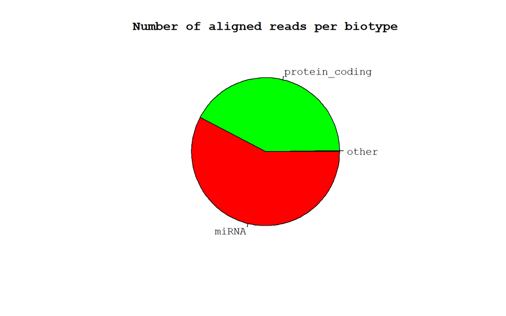

```r
minCount = 40000
typeCountsHigh = typeCounts[typeCounts$x > minCount,]
typeCountsHigh = typeCountsHigh[order(typeCountsHigh$x),]
typeCountsHigh = rbind(data.frame("biotype"="other",
                           "x"=sum(typeCounts$x[typeCounts$x <= minCount])),
                           typeCountsHigh)

pie(typeCountsHigh$x, labels=typeCountsHigh$biotype, col=rev(rainbow(nrow(typeCountsHigh))),
    main="Number of aligned reads per biotype", family ="mono")
```